# Selecting and Tabulating Data with Rich Data Services

## Overview

Access data and metadata together in one quick call, with Rich Data Services (RDS) there is no need to search for documentation or to transcribe it into R. Documentation is provided to users along side the data through the same API call. Variable and classification metadata can accompany any data that is queried through RDS through the use of a few simple parameters.

In this document we will be using data from the American National Election Study 1948 (ANES) that is stored on MTNA’s public RDS server.

## Install

The following packages will be needed for this demonstration.

```r
install.packages("rds.r")
install.packages("htmlTable")
install.packages(sjPlot)
install.packages(ggplot2)
install.packages(plyr)
```

```r
library(rds.r)
library(htmlTable)
library(sjPlot)
library(ggplot2)
library(plyr)
```

## Why RDS?

Traditionally when researchers want to analyze data that is not their own they will have to complete several tasks before they can start their research.

- Locate the data set they want to work with
- Acquire the data and load it in R
- Access the documentation and transcribe the documentation into a useful format in R

RDS cuts down the time it takes for reasearchers to locate and access the data of interest in a particular data set through its innovative querying capabilities and the metadata that can accompany every query.

## Querying data

Lets imagine that we are researching the United States presidential election from 1948, between Harry Truman, and Thomas Dewey. We are interested in demographic data of the respondent and why they did or did not vote for Harry Truman. We may take a look at the documentation on the ANES website https://electionstudies.org/wp-content/uploads/1948/03/anes_timeseries_1948vardoc_codebook.pdf which has a lot of good information about the variables and their codes presented in an ASCII format. However, to identify the variables of interest we would need to read through all 67 variables and their names and labels and choose the variables that have to do with respondent demographics or questions about Truman.

RDS will save you the trouble, instead of manually reading the variables information, we can request the variables and their metadata be returned to us by searching for keywords. This will return more than data, the variable and classification metadata will be available as well. This will allow us to document the variables we are using to provide ourselves and others with more context around the data we are using.

For the purposes of this example we will use the “select” function with keyword parameters to only get columns containing “truman” or “respondent”, as we are interested in the respondents and how they answered questions about Truman.

```r
# We use the select function to hit the anes/anes1948 data product and look for
# cols with the keywords truman and respondent. Metadata is set to true so we can
# see the variables metadata, and we set row limit to 10 to keep this example
# short.
dataSet <- select("http://localhost:8080/rds/api/query/", "anes", "anes1948", cols = "$truman,$respondent",
    metadata = TRUE, rowLimit = 10, autoPage = FALSE)

# get the variable metadata from the data set that was returned and display it in
# a table. variablesMetadata <-
# get.variables('http://localhost:8080/rds/api/catalog/','anes','anes1948',cols='$truman,$respondent',columnLimit=10)
vars <- dataSet@variables
varTable <- htmlTable(vars, col.rgroup = c("none", "#F7F7F7"), css.table = "width: 100%; ",
    css.cell = "padding-left: 2%; padding-right: 2%; font-family:\"Helvetica Neue\",Helvetica,Arial,sans-serif; font-size:14px",
    rnames = FALSE)

# get the data from the data set and display it in a table
data <- dataSet@data
dataTable <- htmlTable(data, col.rgroup = c("none", "#F7F7F7"), css.table = "width: 100%;",
    css.cell = "padding-left: 2%; padding-right: 2%;font-family:\"Helvetica Neue\",Helvetica,Arial,sans-serif; font-size:14px",
    rnames = FALSE)
```

### Dictionary

| uri | classificationUri | dataType | decimals | endPosition | fixedStorageWidth | id | label | name | startPosition |
| --- | --- | --- | --- | --- | --- | --- | --- | --- | --- |
| 85f86183-69bb-4322-9fe2-db42f2db3c82 | f40c6c93-082a-48a2-be85-65e5cb5e6f11 | INT | 0 | 344 | 43 | V480014a | WHY PPL VTD FOR TRUMAN 1 | V480014a | 344 |
| 5a39ffab-cfeb-4611-bd3e-bce06c96f0d2 | f40c6c93-082a-48a2-be85-65e5cb5e6f11 | INT | 0 | 387 | 43 | V480014b | WHY PPL VTD FOR TRUMAN 2 | V480014b | 387 |
| 08ebe970-3d1f-456b-9cca-f651e614868e | 24ebecfb-7045-48d5-a798-4d15563903a6 | INT | 0 | 430 | 43 | V480015a | WHY PPL VTD AGNST TRUMAN 1 | V480015a | 430 |
| d0c1ece8-d7fe-4635-9c47-aabccfc36c66 | 24ebecfb-7045-48d5-a798-4d15563903a6 | INT | 0 | 473 | 43 | V480015b | WHY PPL VTD AGNST TRUMAN 2 | V480015b | 473 |
| bd59de8f-7c95-44da-a321-2bbd79062fc8 | ccbbed5f-6605-4bbe-b4e3-a95dd4e59a32 | INT | 0 | 1207 | 43 | V480031a | GRPS IDENTIFIED W TRUMAN 1 | V480031a | 1207 |
| ede4d896-1491-47c3-a6b6-e4a01dc75062 | ccbbed5f-6605-4bbe-b4e3-a95dd4e59a32 | INT | 0 | 1250 | 43 | V480031b | GRPS IDENTIFIED W TRUMAN 2 | V480031b | 1250 |
| 37801f51-399c-4456-bf9b-6b5dd0169940 | ccbbed5f-6605-4bbe-b4e3-a95dd4e59a32 | INT | 0 | 1293 | 43 | V480031c | GRPS IDENTIFIED W TRUMAN 3 | V480031c | 1293 |
| b762a435-1870-4ec8-bda0-ea9f17c34b6b | a3d55af1-ff28-4f0a-a951-fcd7f07656fa | INT | 0 | 2006 | 9 | V480045 | SEX OF RESPONDENT | V480045 | 2006 |
| c017a329-6e62-4c94-90e8-58c9f6f53fce | 53adaa37-e38e-4916-8c25-1ac889036b26 | INT | 0 | 2015 | 8 | V480046 | RACE OF RESPONDENT | V480046 | 2015 |
| f7edb0ef-7f88-4725-a2f4-ceb964123ef1 | 6f3df474-20be-468a-984c-2491b905a513 | INT | 0 | 2023 | 14 | V480047 | AGE OF RESPONDENT | V480047 | 2023 |
| d90ed8d4-186a-4e85-a827-3c3cceacbb0e | 25f9eba8-94e5-4939-a937-520287b896f0 | INT | 0 | 2037 | 15 | V480048 | EDUCATION OF RESPONDENT | V480048 | 2037 |

### Data

| V480014a | V480014b | V480015a | V480015b | V480031a | V480031b | V480031c | V480045 | V480046 | V480047 | V480048 |
| --- | --- | --- | --- | --- | --- | --- | --- | --- | --- | --- |
| 30 | 91 | 98 | 91 | 10 | 0 | 0 | 1 | 1 | 3 | 1 |
| 30 | 50 | 30 | 91 | 13 | 11 | 0 | 2 | 1 | 3 | 2 |
| 10 | 30 | 30 | 91 | 10 | 0 | 0 | 2 | 1 | 2 | 2 |
| 30 | 91 | 10 | 91 | 11 | 0 | 0 | 2 | 1 | 3 | 3 |
| 30 | 60 | 10 | 91 | 11 | 12 | 0 | 1 | 1 | 2 | 3 |
| 30 | 91 | 99 | 91 | 12 | 11 | 0 | 2 | 1 | 3 | 2 |
| 98 | 91 | 90 | 91 | 0 | 0 | 0 | 1 | 1 | 4 | 1 |
| 50 | 90 | 90 | 91 | 10 | 12 | 0 | 2 | 1 | 5 | 1 |
| 50 | 30 | 30 | 90 | 10 | 0 | 0 | 1 | 1 | 2 | 2 |
| 30 | 90 | 90 | 91 | 0 | 0 | 0 | 1 | 1 | 2 | 2 |

### Data With Code Values

Maybe we want to know the code values for the codes of one or more of these variables, we have two options to do this.

First we could inject the code values into the returned data set as using the **inject** parameter.

```r
# took out colLimit=10
dataSet <- select("http://localhost:8080/rds/api/query/", "anes", "anes1948", rowLimit = 10,
    metadata = TRUE, inject = TRUE)
data <- dataSet@data

dataTable <- htmlTable(data, col.rgroup = c("none", "#F7F7F7"), css.table = "width: 100%;",
    css.cell = "padding-left: 2%; padding-right: 2%; font-family:\"Helvetica Neue\",Helvetica,Arial,sans-serif; font-size:14px",
    rnames = FALSE)
```

VVERSION

VDSETNO

V480001

V480002

V480003

V480004

V480005

V480006

V480007

V480008

V480009

V480010

V480011

V480012

V480013

V480014a

V480014b

V480015a

V480015b

V480016a

V480016b

V480017a

V480017b

V480018

V480019

V480020

V480021a

V480021b

V480022a

V480022b

V480023

V480024

V480025a

V480025b

V480026

V480027

V480028

V480029

V480030

V480031a

V480031b

V480031c

V480032a

V480032b

V480032c

V480033a

V480033b

V480034a

V480034b

V480035a

V480035b

V480036a

V480036b

V480037

V480038

V480039

V480040

V480041

V480042

V480043

V480044

V480045

V480046

V480047

V480048

V480049

V480050

1

1948.T

7218

1001

2. TOWN OR CITY
4. NAME NOT KNOWN
1. ONE CALL
1. YES
9. NA
9. NA
1. INTERVIEWED IN BOTH PRE AND POST
1. DEFINITELY SHOULD BE KEPT ON OR SHOULD
2. SHOULD BE RE-INSTITUTED ON ONE OR A FE
4. SHOULD BE REPEALED
30. EXPECTED – OTHER
30. TRUMAN PRO-LABOR, NEGRO, WORKING MAN
91. NO SECOND REASON
98. DK
91. NO SECOND REASON
70. DEMOCRATS IN OFFICE TOO LONG
90. OTHER REASONS
90. OTHER REASONS
91. NO SECOND REASON
1. VOTED - FOR TRUMAN
1. KNEW ALL ALONG
11. DID NOT CONSIDER ANYONE ELSE
0. NOT APPLICABLE
0. NOT APPLICABLE
90. OTHER REASON
91. INAP
1. TRUMAN - STRAIGHT
0. INAP
91. INAP
91. INAP
0. INAP
1. VOTED PREVIOUSLY – DEMOCRATIC
1. VOTED IN 1944 - ROOSEVELT
70. UNSKILLED, INCLUDING FARM AND SERVICE W
1. YES
10. COMMON MAN, LITTLE PEOPLE
0. NO GROUP, OR NO SECOND, THIRD GROUP
0. NO GROUP, OR NO SECOND, THIRD GROUP
0. NO GROUP
0. NO GROUP
0. NO GROUP
0. NO ISSUE
0. NO ISSUE
0. NO ISSUE
0. NO ISSUE
0. NO ATTRIBUTE MENTIONED
0. NO ATTRIBUTE MENTIONED
0. NO ATTRIBUTE MENTIONED
0. NO ATTRIBUTE MENTIONED
0. NO INCIDENT MENTIONED
1. ALMOST CERTAIN TO V4800OTE
1. DEMOCRATIC
1. AGREE
4. DISSATISFIED OR WITH RESERVATIONS
2. MEDIUM INFORMATION
4. NO OR DISAPPROVE WITH RESERVATIONS OR
4. NO, WITH RESERVATIONS
1. MALE
1. WHITE
3. 35-44
1. GRADE SCHOOL

4.$2000-2999

1. PROTESTANT

1

1948.T

7218

1002

1. METROPOLITAN AREA
4. NAME NOT KNOWN
2. TWO CALLS
1. YES
2. NO
1. PREVIOUS RESPONDENT INTERVIEWED
1. INTERVIEWED IN BOTH PRE AND POST
2. SHOULD BE KEPT WITH RESTRICTIONS, OR R
5. PRICE CONTROL SHOULD BE KEPT OFF
1. SHOULD BE LEFT ALONE
19. SURPRISED – NA WHY
30. TRUMAN PRO-LABOR, NEGRO, WORKING MAN
50. DEMOCRATS MEAN PROSPERITY, REPUBLICANS
30. CAN’T GET THINGS DONE
91. NO SECOND REASON
20. EXPERIENCED
91. NO SECOND REASON
20. COLD PERSONALITY, INHUMAN, SUPERIOR, AP
91. NO SECOND REASON
2. VOTED - FOR DEWEY
1. KNEW ALL ALONG
22. DID NOT CONSIDER ANYONE ELSE
0. NOT APPLICABLE
0. NOT APPLICABLE
40. FOREIGN POLICY
30. DOMESTIC PLATFORM AND ISSUES
3. DEWEY - STRAIGHT
0. INAP
91. INAP
91. INAP
0. INAP
2. VOTED PREVIOUSLY – REPUBLICAN
2. VOTED IN 1944 - DEWEY
30. OTHER WHITE-COLLAR (CLERICAL, SALES, ET
2. NO
13. GOVERNMENT WORKER
11. ORGANIZED LABOR, UNIONS
0. NO GROUP, OR NO SECOND, THIRD GROUP
0. NO GROUP
0. NO GROUP
0. NO GROUP
83. TAFT-HARTLEY
0. NO ISSUE
0. NO ISSUE
0. NO ISSUE
22. SMALL, INCOMPETENT, INEFFICIENT
0. NO ATTRIBUTE MENTIONED
12. EXPERIENCED, CAPABLE, COMPETENT, INTELL
0. NO ATTRIBUTE MENTIONED
0. NO INCIDENT MENTIONED
1. ALMOST CERTAIN TO V4800OTE
3. REPUBLICAN
1. AGREE
5. VERY DISSATISFIED
2. MEDIUM INFORMATION
2. APPROVE WITH RESERVATIONS OR UNCERTAIN
4. NO, WITH RESERVATIONS
2. FEMALE
1. WHITE
3. 35-44
2. HIGH SCHOOL

7.$5000 AND OVER

1. PROTESTANT

1

1948.T

7218

1003

1. METROPOLITAN AREA
4. NAME NOT KNOWN
1. ONE CALL
1. YES
1. YES
1. PREVIOUS RESPONDENT INTERVIEWED
1. INTERVIEWED IN BOTH PRE AND POST
1. DEFINITELY SHOULD BE KEPT ON OR SHOULD
5. PRICE CONTROL SHOULD BE KEPT OFF
0. HAVE NOT HEARD ABOUT TAFT-HARTLEY ACT
14. SURPRISED – OTHER, MISCELLANEOUS
10. BETTER MAN
30. TRUMAN PRO-LABOR, NEGRO, WORKING MAN
30. CAN’T GET THINGS DONE
91. NO SECOND REASON
70. DEMOCRATS IN OFFICE TOO LONG
10. BETTER MAN
40. OVER-CONFIDENT
20. COLD PERSONALITY, INHUMAN, SUPERIOR, AP
1. VOTED - FOR TRUMAN
1. KNEW ALL ALONG
11. DID NOT CONSIDER ANYONE ELSE
0. NOT APPLICABLE
0. NOT APPLICABLE
70. PARTY ALLEGIANCE - ALWAYS VOTE FOR SAME
91. INAP
1. TRUMAN - STRAIGHT
0. INAP
91. INAP
91. INAP
0. INAP
1. VOTED PREVIOUSLY – DEMOCRATIC
1. VOTED IN 1944 - ROOSEVELT
40. SKILLED AND SEMI-SKILLED
2. NO
10. COMMON MAN, LITTLE PEOPLE
0. NO GROUP, OR NO SECOND, THIRD GROUP
0. NO GROUP, OR NO SECOND, THIRD GROUP
0. NO GROUP
0. NO GROUP
0. NO GROUP
0. NO ISSUE
0. NO ISSUE
0. NO ISSUE
0. NO ISSUE
23. INDECISIVE, VACILLATING, DOESN’T KNOW H
0. NO ATTRIBUTE MENTIONED
24. FOPPISH, OVER-DRESSED, APPEARANCE ANTAG
25. SMUG, COMPLACENT, OVER-CONFIDENT, PATRO
0. NO INCIDENT MENTIONED
1. ALMOST CERTAIN TO V4800OTE
8. DK
5. DISAGREE
4. DISSATISFIED OR WITH RESERVATIONS
1. LOW INFORMATION
5. NO OR DISAPPROVE
5. NO
2. FEMALE
1. WHITE
2. 25-34
2. HIGH SCHOOL

5.$3000-3999

2. CATHOLIC

1

1948.T

7218

1004

2. TOWN OR CITY
4. NAME NOT KNOWN
1. ONE CALL
1. YES
1. YES
1. PREVIOUS RESPONDENT INTERVIEWED
1. INTERVIEWED IN BOTH PRE AND POST
1. DEFINITELY SHOULD BE KEPT ON OR SHOULD
1. SHOULD BE RE-INSTITUTED ON ALL OR MANY
5. HAVE HEARD OF TAFT-HARTLEY ACT
11. SURPRISED – EXPERTS, RADIO, PAPERS SA
30. TRUMAN PRO-LABOR, NEGRO, WORKING MAN
91. NO SECOND REASON
10. SMALL MAN, INADEQUATE BACKGROUND
91. NO SECOND REASON
70. DEMOCRATS IN OFFICE TOO LONG
20. EXPERIENCED
50. CONDUCTED POOR CAMPAIGN, NON-COMMITAL O
91. NO SECOND REASON
2. VOTED - FOR DEWEY
2. DECIDED AT TIME OF CONVENTION
22. DID NOT CONSIDER ANYONE ELSE
0. NOT APPLICABLE
0. NOT APPLICABLE
80. TAUTOLOGICAL - VOTED FOR BEST MAN
91. INAP
3. DEWEY - STRAIGHT
0. INAP
91. INAP
91. INAP
0. INAP
2. VOTED PREVIOUSLY – REPUBLICAN
2. VOTED IN 1944 - DEWEY
10. PROFESSIONAL, SEMI-PROFESSIONAL
2. NO
11. ORGANIZED LABOR, UNIONS
0. NO GROUP, OR NO SECOND, THIRD GROUP
0. NO GROUP, OR NO SECOND, THIRD GROUP
0. NO GROUP
0. NO GROUP
0. NO GROUP
0. NO ISSUE
0. NO ISSUE
0. NO ISSUE
0. NO ISSUE
22. SMALL, INCOMPETENT, INEFFICIENT
0. NO ATTRIBUTE MENTIONED
12. EXPERIENCED, CAPABLE, COMPETENT, INTELL
27. NON-COMMITTAL, BACKS AWAY FROM ISSUES,
0. NO INCIDENT MENTIONED
1. ALMOST CERTAIN TO V4800OTE
3. REPUBLICAN
4. DISAGREE WITH RESERVATIONS OR UNCERTAI
4. DISSATISFIED OR WITH RESERVATIONS
1. LOW INFORMATION
4. NO OR DISAPPROVE WITH RESERVATIONS OR
5. NO
2. FEMALE
1. WHITE
3. 35-44
3. COLLEGE

7.$5000 AND OVER

1. PROTESTANT

1

1948.T

7218

1005

1. METROPOLITAN AREA
4. NAME NOT KNOWN
2. TWO CALLS
1. YES
2. NO
1. PREVIOUS RESPONDENT INTERVIEWED
1. INTERVIEWED IN BOTH PRE AND POST
1. DEFINITELY SHOULD BE KEPT ON OR SHOULD
5. PRICE CONTROL SHOULD BE KEPT OFF
1. SHOULD BE LEFT ALONE
27. EXPECTED – LABOR, NEGRO, GOVERNMENT E
30. TRUMAN PRO-LABOR, NEGRO, WORKING MAN
60. TRUMAN PRO RENT CONTROL, PRICE CONTROL,
10. SMALL MAN, INADEQUATE BACKGROUND
91. NO SECOND REASON
10. BETTER MAN
91. NO SECOND REASON
20. COLD PERSONALITY, INHUMAN, SUPERIOR, AP
60. DEWEY PRO-80TH CONGRESS
1. VOTED - FOR TRUMAN
2. DECIDED AT TIME OF CONVENTION
11. DID NOT CONSIDER ANYONE ELSE
0. NOT APPLICABLE
0. NOT APPLICABLE
90. OTHER REASON
70. PARTY ALLEGIANCE - ALWAYS VOTE FOR SAME
2. TRUMAN - SPLIT
0. INAP
91. INAP
91. INAP
0. INAP
1. VOTED PREVIOUSLY – DEMOCRATIC
1. VOTED IN 1944 - ROOSEVELT
10. PROFESSIONAL, SEMI-PROFESSIONAL
2. NO
11. ORGANIZED LABOR, UNIONS
12. FARMER
0. NO GROUP, OR NO SECOND, THIRD GROUP
0. NO GROUP
0. NO GROUP
0. NO GROUP
19. FARM PRICES AND SUPPORT
83. TAFT-HARTLEY
81. RENT CONTROL
3. TAFT-HARTLEY
22. SMALL, INCOMPETENT, INEFFICIENT
0. NO ATTRIBUTE MENTIONED
25. SMUG, COMPLACENT, OVER-CONFIDENT, PATRO
12. EXPERIENCED, CAPABLE, COMPETENT, INTELL
0. NO INCIDENT MENTIONED
1. ALMOST CERTAIN TO V4800OTE
1. DEMOCRATIC
4. DISAGREE WITH RESERVATIONS OR UNCERTAI
5. VERY DISSATISFIED
2. MEDIUM INFORMATION
6. IT DEPENDS
5. NO
1. MALE
1. WHITE
2. 25-34
3. COLLEGE

5.$3000-3999

2. CATHOLIC

1

1948.T

7218

1006

1. METROPOLITAN AREA
4. NAME NOT KNOWN
2. TWO CALLS
1. YES
1. YES
1. PREVIOUS RESPONDENT INTERVIEWED
1. INTERVIEWED IN BOTH PRE AND POST
1. DEFINITELY SHOULD BE KEPT ON OR SHOULD
1. SHOULD BE RE-INSTITUTED ON ALL OR MANY
6. HAVE HEARD OF TAFT-HARTLEY ACT
14. SURPRISED – OTHER, MISCELLANEOUS
30. TRUMAN PRO-LABOR, NEGRO, WORKING MAN
91. NO SECOND REASON
99. NA
91. NO SECOND REASON
20. EXPERIENCED
91. NO SECOND REASON
50. CONDUCTED POOR CAMPAIGN, NON-COMMITAL O
90. OTHER REASONS
2. VOTED - FOR DEWEY
2. DECIDED AT TIME OF CONVENTION
22. DID NOT CONSIDER ANYONE ELSE
0. NOT APPLICABLE
0. NOT APPLICABLE
90. OTHER REASON
91. INAP
3. DEWEY - STRAIGHT
0. INAP
91. INAP
91. INAP
0. INAP
2. VOTED PREVIOUSLY – REPUBLICAN
2. VOTED IN 1944 - DEWEY
20. SELF-EMPLOYED, MANAGERIAL, SUPERVISORY
2. NO
12. FARMER
11. ORGANIZED LABOR, UNIONS
0. NO GROUP, OR NO SECOND, THIRD GROUP
0. NO GROUP
0. NO GROUP
0. NO GROUP
68. TAFT-HARTLEY
0. NO ISSUE
0. NO ISSUE
0. NO ISSUE
0. NO ATTRIBUTE MENTIONED
0. NO ATTRIBUTE MENTIONED
12. EXPERIENCED, CAPABLE, COMPETENT, INTELL
0. NO ATTRIBUTE MENTIONED
0. NO INCIDENT MENTIONED
1. ALMOST CERTAIN TO V4800OTE
3. REPUBLICAN
2. AGREE WITH RESERVATIONS OR UNCERTAINTY
4. DISSATISFIED OR WITH RESERVATIONS
0. NO INFORMATION
4. NO OR DISAPPROVE WITH RESERVATIONS OR
5. NO
2. FEMALE
1. WHITE
3. 35-44
2. HIGH SCHOOL

7.$5000 AND OVER

1. PROTESTANT

1

1948.T

7218

1007

3. OPEN COUNTRY
4. NAME NOT KNOWN
1. ONE CALL
1. YES
1. YES
1. PREVIOUS RESPONDENT INTERVIEWED
1. INTERVIEWED IN BOTH PRE AND POST
4. SHOULD BE DROPPED
5. PRICE CONTROL SHOULD BE KEPT OFF
7. SHOULD BE CHANGED, NA HOW
19. SURPRISED – NA WHY
98. DK
91. NO SECOND REASON
90. OTHER REASONS
91. NO SECOND REASON
10. BETTER MAN
70. DEMOCRATS IN OFFICE TOO LONG
20. COLD PERSONALITY, INHUMAN, SUPERIOR, AP
30. PARTIAL TO BUSINESS, WALL STREET PRESID
2. VOTED - FOR DEWEY
1. KNEW ALL ALONG
22. DID NOT CONSIDER ANYONE ELSE
0. NOT APPLICABLE
0. NOT APPLICABLE
70. PARTY ALLEGIANCE - ALWAYS VOTE FOR SAME
90. OTHER REASON
9. NA
0. INAP
91. INAP
91. INAP
0. INAP
2. VOTED PREVIOUSLY – REPUBLICAN
2. VOTED IN 1944 - DEWEY
80. FARM OPERATORS AND MANAGERS
2. NO
0. NO GROUP, OR NO SECOND, THIRD GROUP
0. NO GROUP, OR NO SECOND, THIRD GROUP
0. NO GROUP, OR NO SECOND, THIRD GROUP
14. BUSINESS, BIG MONEY, UPPER CLASSES, WAL
0. NO GROUP
0. NO GROUP
0. NO ISSUE
0. NO ISSUE
0. NO ISSUE
0. NO ISSUE
23. INDECISIVE, VACILLATING, DOESN’T KNOW H
0. NO ATTRIBUTE MENTIONED
12. EXPERIENCED, CAPABLE, COMPETENT, INTELL
25. SMUG, COMPLACENT, OVER-CONFIDENT, PATRO
0. NO INCIDENT MENTIONED
1. ALMOST CERTAIN TO V4800OTE
3. REPUBLICAN
1. AGREE
8. DK
3. HIGH INFORMATION
2. APPROVE WITH RESERVATIONS OR UNCERTAIN
5. NO
1. MALE
1. WHITE
4. 45-54
1. GRADE SCHOOL

5.$3000-3999

1. PROTESTANT

1

1948.T

7218

1008

3. OPEN COUNTRY
4. NAME NOT KNOWN
1. ONE CALL
1. YES
1. YES
1. PREVIOUS RESPONDENT INTERVIEWED
1. INTERVIEWED IN BOTH PRE AND POST
1. DEFINITELY SHOULD BE KEPT ON OR SHOULD
1. SHOULD BE RE-INSTITUTED ON ALL OR MANY
5. HAVE HEARD OF TAFT-HARTLEY ACT
27. EXPECTED – LABOR, NEGRO, GOVERNMENT E
50. DEMOCRATS MEAN PROSPERITY, REPUBLICANS
90. OTHER
90. OTHER REASONS
91. NO SECOND REASON
90. OTHER REASONS
90. OTHER REASONS
70. NOTHING SPECIAL ABOUT DEWEY MADE PEOPLE
91. NO SECOND REASON
1. VOTED - FOR TRUMAN
1. KNEW ALL ALONG
11. DID NOT CONSIDER ANYONE ELSE
0. NOT APPLICABLE
0. NOT APPLICABLE
90. OTHER REASON
91. INAP
2. TRUMAN - SPLIT
0. INAP
91. INAP
91. INAP
0. INAP
4. VOTED PREVIOUSLY – MORE THAN ONE PART
1. VOTED IN 1944 - ROOSEVELT
80. FARM OPERATORS AND MANAGERS
2. NO
10. COMMON MAN, LITTLE PEOPLE
12. FARMER
0. NO GROUP, OR NO SECOND, THIRD GROUP
0. NO GROUP
0. NO GROUP
0. NO GROUP
0. NO ISSUE
0. NO ISSUE
77. MARSHALL PLAN
0. NO ISSUE
0. NO ATTRIBUTE MENTIONED
0. NO ATTRIBUTE MENTIONED
25. SMUG, COMPLACENT, OVER-CONFIDENT, PATRO
0. NO ATTRIBUTE MENTIONED
0. NO INCIDENT MENTIONED
1. ALMOST CERTAIN TO V4800OTE
1. DEMOCRATIC
4. DISAGREE WITH RESERVATIONS OR UNCERTAI
4. DISSATISFIED OR WITH RESERVATIONS
3. HIGH INFORMATION
4. NO OR DISAPPROVE WITH RESERVATIONS OR
9. NA
2. FEMALE
1. WHITE
5. 55-64
1. GRADE SCHOOL

2.$500-$999

1. PROTESTANT

1

1948.T

7218

1009

2. TOWN OR CITY
4. NAME NOT KNOWN
1. ONE CALL
1. YES
1. YES
1. PREVIOUS RESPONDENT INTERVIEWED
1. INTERVIEWED IN BOTH PRE AND POST
1. DEFINITELY SHOULD BE KEPT ON OR SHOULD
5. PRICE CONTROL SHOULD BE KEPT OFF
5. HAVE HEARD OF TAFT-HARTLEY ACT
11. SURPRISED – EXPERTS, RADIO, PAPERS SA
50. DEMOCRATS MEAN PROSPERITY, REPUBLICANS
30. TRUMAN PRO-LABOR, NEGRO, WORKING MAN
30. CAN’T GET THINGS DONE
90. OTHER REASONS
90. OTHER REASONS
90. OTHER REASONS
30. PARTIAL TO BUSINESS, WALL STREET PRESID
91. NO SECOND REASON
2. VOTED - FOR DEWEY
1. KNEW ALL ALONG
22. DID NOT CONSIDER ANYONE ELSE
0. NOT APPLICABLE
0. NOT APPLICABLE
70. PARTY ALLEGIANCE - ALWAYS VOTE FOR SAME
91. INAP
3. DEWEY - STRAIGHT
0. INAP
91. INAP
91. INAP
0. INAP
2. VOTED PREVIOUSLY – REPUBLICAN
2. VOTED IN 1944 - DEWEY
40. SKILLED AND SEMI-SKILLED
1. YES
10. COMMON MAN, LITTLE PEOPLE
0. NO GROUP, OR NO SECOND, THIRD GROUP
0. NO GROUP, OR NO SECOND, THIRD GROUP
14. BUSINESS, BIG MONEY, UPPER CLASSES, WAL
0. NO GROUP
0. NO GROUP
0. NO ISSUE
0. NO ISSUE
0. NO ISSUE
0. NO ISSUE
23. INDECISIVE, VACILLATING, DOESN’T KNOW H
0. NO ATTRIBUTE MENTIONED
0. NO ATTRIBUTE MENTIONED
0. NO ATTRIBUTE MENTIONED
0. NO INCIDENT MENTIONED
1. ALMOST CERTAIN TO V4800OTE
3. REPUBLICAN
4. DISAGREE WITH RESERVATIONS OR UNCERTAI
4. DISSATISFIED OR WITH RESERVATIONS
1. LOW INFORMATION
2. APPROVE WITH RESERVATIONS OR UNCERTAIN
8. DK
1. MALE
1. WHITE
2. 25-34
2. HIGH SCHOOL

5.$3000-3999

1. PROTESTANT

1

1948.T

7218

1010

2. TOWN OR CITY
4. NAME NOT KNOWN
1. ONE CALL
1. YES
1. YES
1. PREVIOUS RESPONDENT INTERVIEWED
1. INTERVIEWED IN BOTH PRE AND POST
1. DEFINITELY SHOULD BE KEPT ON OR SHOULD
1. SHOULD BE RE-INSTITUTED ON ALL OR MANY
4. SHOULD BE REPEALED
10. SURPRISED – THOUGHT PEOPLE WANTED CHA
30. TRUMAN PRO-LABOR, NEGRO, WORKING MAN
90. OTHER
90. OTHER REASONS
91. NO SECOND REASON
70. DEMOCRATS IN OFFICE TOO LONG
30. DEWEY PRO BUSINESS, WEALTHY, TRUMAN PRO
90. OTHER REASONS
91. NO SECOND REASON
1. VOTED - FOR TRUMAN
2. DECIDED AT TIME OF CONVENTION
11. DID NOT CONSIDER ANYONE ELSE
0. NOT APPLICABLE
0. NOT APPLICABLE
90. OTHER REASON
91. INAP
1. TRUMAN - STRAIGHT
0. INAP
91. INAP
91. INAP
0. INAP
6. HAVE NEVER VOTED PREVIOUS PRESIDENTIAL
5. DID NOT VOTE IN 1944
40. SKILLED AND SEMI-SKILLED
1. YES
0. NO GROUP, OR NO SECOND, THIRD GROUP
0. NO GROUP, OR NO SECOND, THIRD GROUP
0. NO GROUP, OR NO SECOND, THIRD GROUP
14. BUSINESS, BIG MONEY, UPPER CLASSES, WAL
0. NO GROUP
0. NO GROUP
0. NO ISSUE
0. NO ISSUE
0. NO ISSUE
0. NO ISSUE
12. EXPERIENCED, CAPABLE, COMPETENT, INTELL
0. NO ATTRIBUTE MENTIONED
0. NO ATTRIBUTE MENTIONED
0. NO ATTRIBUTE MENTIONED
0. NO INCIDENT MENTIONED
1. ALMOST CERTAIN TO V4800OTE
1. DEMOCRATIC
4. DISAGREE WITH RESERVATIONS OR UNCERTAI
4. DISSATISFIED OR WITH RESERVATIONS
2. MEDIUM INFORMATION
2. APPROVE WITH RESERVATIONS OR UNCERTAIN
5. NO
1. MALE
1. WHITE
2. 25-34
2. HIGH SCHOOL

6.$4000-4999

2. CATHOLIC

### Sex of Respondent: Classification

We could also simply access the classification information for a given variable. We will take the classification URI from the “Sex of Respondent” variable and get teh classification for it.

```r
V480045 <- rds.r:::variable(dataSet@variables, "V480045")
classification <- rds.r::get.classification("http://localhost:8080/rds/api/catalog/",
    "anes", "anes1948", class.id = V480045$classificationUri)
classTable <- htmlTable(classification, col.rgroup = c("none", "#F7F7F7"), css.table = "width: 100%;",
    rnames = FALSE)
```

codeValue

name

uri

1

1. MALE

de9699a2-0aca-4364-b432-93405d54a5b4

2

2. FEMALE

d475064a-0c36-41eb-96cd-c282bdbaad2a

9

9. NA

07ab4577-c495-4e11-93b8-6c09058872c5

## Tabulating Data

Perhaps we would like to know if there is any difference between why male and female respondents think people voted for Truman. First lets create the table using the **tabulate** function.

```r
tabulation <- rds.r::tabulate("http://localhost:8080/rds/api/query/", "anes", "anes1948",
    metadata = TRUE, dimensions = "V480045,V480014a", inject = TRUE)
data <- tabulation@data
variables <- tabulation@variables
variableNames <- list()
variableNames <- variables$label
table <- sjtable <- sjt.xtab(data$V480045, data$V480014a, var.labels = variableNames)
```

SEX OF RESPONDENT

WHY PPL VTD FOR  
TRUMAN 1

Total

10. BETTER MAN
20. EXPERIENCED,  
    GOOD RECORD
30. TRUMAN  
    PRO-LABOR, NEGRO,  
    WORKING MAN
40. GOOD CAMPAIGN  
    CONDUCTED BY TRUMAN
50. DEMOCRATS MEAN  
    PROSPERITY,  
    REPUBLICANS
60. TRUMAN PRO RENT  
    CONTROL, PRICE  
    CONTROL,
70. ROOSEVELT  
    TRADITION
80. PERSONAL  
    ATTRIBUTES
90. OTHER
98. DK
99. NA
1. MALE

1

1

1

1

1

1

1

1

1

1

1

11

2. FEMALE

1

1

1

1

1

1

1

1

1

1

1

11

9. NA

0

0

0

0

0

0

0

0

0

0

1

1

Total

2

2

2

2

2

2

2

2

2

2

3

23

χ<sup>2</sup>=6.970 · df=20 · Cramer’s V=0.389 · Fisher’s p=1.000

## Turning Tabulations into Charts

Because the tabulate function returns a data set that contains the data and metadata, all we need to do is plug in the appropriate data and metadata into our favorite charting tool.

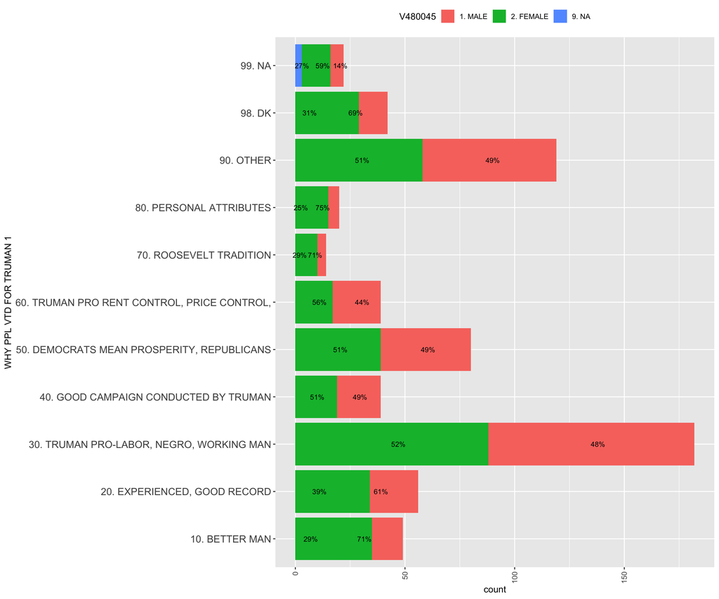

```r
variables <- tabulation@variables
V480045 <- rds.r:::variable(variables, "V480045")
V480014a <- rds.r:::variable(variables, "V480014a")

## we will compute the percentage and format it as a percentage label for the
## chart
data$count <- as.numeric(as.character(data$count))
data = ddply(data, .(V480014a), transform, Pct = count/sum(count) * 100)
data = ddply(data, .(V480014a), transform, pos = (cumsum(count) - 0.5 * count))
data$label = paste0(sprintf("%.0f", data$Pct), "%")

# plot the data
ggplot(data, aes(x = factor(V480014a), y = count, fill = V480045)) + geom_bar(stat = "identity") +
    geom_text(aes(y = pos, label = label), size = 3) + theme(axis.text.x = element_text(angle = 90,
    hjust = 1, vjust = 0.5), axis.text.y = element_text(size = 12), legend.position = "top") +
    xlab(V480014a$label) + coord_flip()
```